# DBSCAN在R的操作

Chia-Jung, Yeh

2021-07-08

## R 下載 DBSCAN 套件

在R裡面有許多套件支援 DBSCAN 的分群，其中一個最常見的就是`dbscan`，必須先安裝並導入。

```r
install.packages("dbscan")
library(dbscan)
```

## 程式碼撰寫

以下是你的程式碼：

```r
data=read.csv("./變數.csv", sep=",", header=T)

data[(data=="" | data==" " | data=="  ")]=NA

data$public=ifelse(is.na(data$public), 1, data$public)
data$private=ifelse(is.na(data$private), 0, data$private)
data$PPP=ifelse(is.na(data$PPP), 0, data$PPP)

data$urban=ifelse(is.na(data$urban), 0, data$urban)
data$urban.or.rural=ifelse(is.na(data$urban.or.rural), 1, data$urban.or.rural)
data$rural=ifelse(is.na(data$rural), 0, data$rural)
```

上面 data 的資料格式是 dataframe，不過在 `dbscan()` 的輸入資料必須是 matrix，因此我們必須先把 data 轉換為 matrix 的形式。注意第一個欄位是 DRTS 路線的名稱，並非 dbscan 可處理的欄位，必須先剔除之。

```r
data_mat=as.matrix(data[, 2:18])
```

dbscan 演算法的分群方法說明如下。DBSCAN (Density-based spatial clustering of applications with noise)演算法是以密度為基礎，利用資料分布的密集度將密度高的區域形成數個群集，而相對密度低者或零散資料點則視為雜訊或偏離值。DBSCAN 必須設定兩參數，一是鄰近區域的半徑（Eps），為每次探訪資料點的半徑，半徑愈大，分群的數目可能愈少；另一參數則為鄰近區域的最小點數（MinPts），若半徑（Eps）內之資料點數大於最小點數（MinPts），則將所有點資料劃分至同一群集中，若小於最小點數（MinPts）則將該資料群視為雜訊。根據上述參數的設定即可重複執行迭代演算，直至當前所有點無法再分類至該群集中。接著再自一個未曾訪問的資料點中選取其一資料，重複上述步驟完成所有資料點的聚類，直至所有資料點皆訪問完畢。

DBSCAN 演算程序整理如下圖所示。圖中假設半徑（Eps）為 ε，最小點數（MinPts）為 4，亦即每一次尋找群集時，需檢查半徑內是否有 4 個點，若有 則將所有點劃分至同一群集中。步驟①乃以 A 點為中心， ε 為半徑，將 A、 B、C、 D 四點劃分於同一範圍內，故四點歸類於同一群集。接著步驟②再以 B 點為中心， ε 為半徑，將 A、 B、 C、 E、 F五點劃分於同一範圍中，故亦歸類於同一群集中。以次類推，及至所有圖中的點劃分完畢後，剩餘無法歸類在任何一群集中的點即為噪點（noise），如圖中的 I 點。

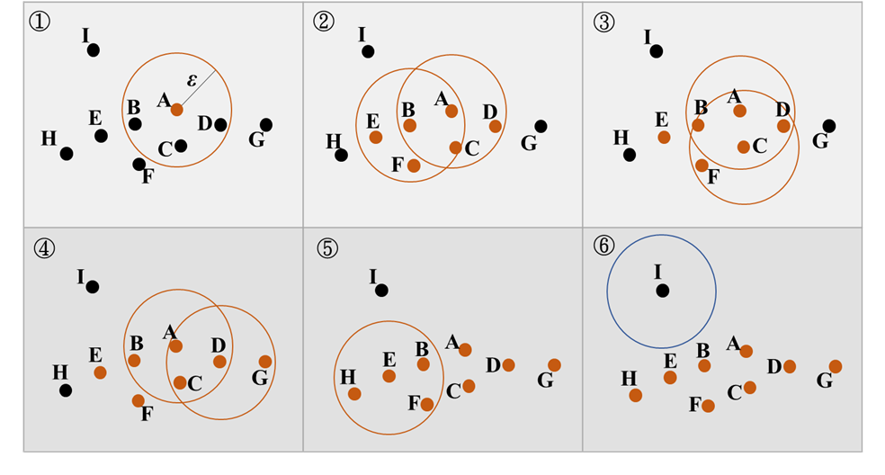

dbscan 函式中須設定最大搜尋半徑和最小分群數目，在 data 這個資料中，eps 就是指所有變數的幾何距離（Euclidean Distance），譬如(0,1,1)和(1,0,1)兩個樣本的距離就會是√2。在 data 這組資料中，因為所有的變數都是0或1，所以最大距離其實就是一組「全為0的資料」，和一組「全為1的資料」兩者間的距離，也就是17√2（我們總共有17個變數~）。如果我們 eps 半徑設定的越大，就會使所有 DRTS 路線被我們分類到同一個類群中，這樣其實不是合理的分類結果；但半徑設太小，反而會產生非常多噪點，也不是我們預期的結果。 MinPts 表示每一個類群中最少的 DRTS 路線數。以下我們先來做隨機試驗：

假設搜尋半徑設定為1，類群最少路線數是2條

```r
db = dbscan(data_mat, eps=1, minPts=2)
db$cluster
```

```
##  [1]  1  2  1  0  0  2  3  2  4  0  5  6  0  0  4  0  0  5  7  8  8  6  6  3  7
## [26]  0  7  0  0  9  0  0  9  9  9  0  0  0 10  0 10 10  0  0 10
```

程式碼中`db$cluster`表示每一條路線所分到的類組，如果數字是0，表示該條路線為噪點，無法分類在任何一群中。接著可以把這組向量和原本我們的 data 資料合併，就可以更明確了解各路線的分群（如表格最後一欄位所示）。

```r
cbind(data, cluster=db$cluster)
```

| X | public | private | PPP | urban | urban.or.rural | rural | virtual | PT.stop | D2D | Door.to.station | virtual.to.station | fixed.route | DRT | mixed.route | phone | web | APP | cluster |
| --- | --- | --- | --- | --- | --- | --- | --- | --- | --- | --- | --- | --- | --- | --- | --- | --- | --- | --- |
| BT let’s go | 1 | 0 | 0 | 1 | 0 | 0 | 0 | 1 | 0 | 0 | 0 | 1 | 0 | 0 | 1 | 1 | 1 | 1 |
| Mobility bus | 1 | 0 | 0 | 1 | 0 | 0 | 0 | 0 | 1 | 0 | 0 | 0 | 1 | 0 | 1 | 1 | 1 | 2 |
| Edmonton Transit Service | 1 | 0 | 0 | 1 | 0 | 0 | 0 | 1 | 0 | 0 | 0 | 1 | 0 | 0 | 1 | 1 | 1 | 1 |
| NRT OnDemand | 1 | 0 | 0 | 0 | 0 | 1 | 0 | 1 | 1 | 0 | 0 | 0 | 0 | 1 | 1 | 0 | 1 | 0 |
| Chair-A-Van | 1 | 0 | 0 | 0 | 0 | 1 | 1 | 0 | 0 | 0 | 0 | 1 | 0 | 0 | 1 | 0 | 1 | 0 |
| Wheel-Trans | 1 | 0 | 0 | 1 | 0 | 0 | 0 | 0 | 1 | 0 | 0 | 0 | 1 | 0 | 1 | 0 | 0 | 2 |
| Dial-a-Ride transit | 1 | 0 | 0 | 0 | 1 | 0 | 0 | 1 | 1 | 0 | 0 | 0 | 0 | 1 | 1 | 0 | 1 | 3 |
| Transit Plus (Handi-Transit) | 1 | 0 | 0 | 1 | 0 | 0 | 0 | 0 | 1 | 0 | 0 | 0 | 1 | 0 | 1 | 1 | 0 | 2 |
| Kan-go | 1 | 0 | 0 | 0 | 1 | 0 | 0 | 0 | 0 | 1 | 0 | 0 | 0 | 1 | 1 | 1 | 0 | 4 |
| Telebus | 1 | 0 | 0 | 0 | 0 | 1 | 0 | 0 | 1 | 1 | 0 | 0 | 0 | 1 | 1 | 1 | 0 | 0 |
| Keolis Downer | 1 | 0 | 0 | 1 | 0 | 0 | 1 | 0 | 0 | 0 | 0 | 1 | 0 | 0 | 1 | 1 | 1 | 5 |
| Butler Area Rural Transit (BART) | 1 | 0 | 0 | 0 | 0 | 1 | 0 | 0 | 1 | 0 | 0 | 0 | 1 | 0 | 1 | 1 | 0 | 6 |
| Bay area rapid transit (BART) | 1 | 0 | 0 | 1 | 0 | 0 | 0 | 1 | 0 | 1 | 0 | 0 | 0 | 1 | 1 | 1 | 1 | 0 |
| FlexRide (Call-n-Ride service) | 1 | 0 | 0 | 0 | 1 | 0 | 1 | 1 | 0 | 1 | 0 | 0 | 0 | 1 | 1 | 1 | 1 | 0 |
| Flex Service | 1 | 0 | 0 | 0 | 1 | 0 | 0 | 0 | 1 | 1 | 0 | 0 | 0 | 1 | 1 | 1 | 0 | 4 |
| NeighborLink | 1 | 0 | 0 | 0 | 0 | 1 | 0 | 0 | 1 | 1 | 0 | 0 | 1 | 0 | 1 | 1 | 1 | 0 |
| Pace On Demand | 1 | 0 | 0 | 0 | 1 | 0 | 0 | 1 | 0 | 0 | 0 | 1 | 0 | 0 | 1 | 1 | 1 | 0 |
| Ride on Flex | 1 | 0 | 0 | 1 | 0 | 0 | 1 | 0 | 0 | 0 | 0 | 1 | 0 | 0 | 1 | 1 | 1 | 5 |
| Access-A-Ride | 1 | 0 | 0 | 0 | 1 | 0 | 0 | 0 | 1 | 0 | 0 | 0 | 1 | 0 | 1 | 1 | 0 | 7 |
| Bee-Line Paratransit | 1 | 0 | 0 | 0 | 1 | 0 | 1 | 0 | 1 | 0 | 0 | 1 | 1 | 0 | 1 | 0 | 0 | 8 |
| Qualla Community Resident Transportation | 1 | 0 | 0 | 0 | 1 | 0 | 1 | 0 | 1 | 0 | 0 | 1 | 1 | 0 | 1 | 0 | 0 | 8 |
| Night Shuttle | 1 | 0 | 0 | 0 | 0 | 1 | 0 | 0 | 1 | 0 | 0 | 0 | 1 | 0 | 1 | 0 | 0 | 6 |
| Rural General Public Program | 1 | 0 | 0 | 0 | 0 | 1 | 0 | 0 | 1 | 0 | 0 | 0 | 1 | 0 | 1 | 0 | 0 | 6 |
| DARTS (Dial-A-Ride Transportation Services) | 1 | 0 | 0 | 0 | 1 | 0 | 0 | 1 | 1 | 0 | 0 | 0 | 0 | 1 | 1 | 0 | 0 | 3 |
| Rural General Public (RGP) | 1 | 0 | 0 | 0 | 1 | 0 | 0 | 0 | 1 | 0 | 0 | 0 | 1 | 0 | 1 | 0 | 0 | 7 |
| Tel-A-Ride Service | 1 | 0 | 0 | 0 | 1 | 0 | 1 | 0 | 0 | 0 | 0 | 1 | 0 | 0 | 1 | 0 | 1 | 0 |
| MetroAccess Paratransit | 1 | 0 | 0 | 0 | 1 | 0 | 0 | 0 | 1 | 0 | 0 | 0 | 1 | 0 | 1 | 1 | 0 | 7 |
| Netliner | 1 | 0 | 0 | 0 | 1 | 0 | 1 | 1 | 0 | 0 | 0 | 1 | 0 | 0 | 1 | 1 | 0 | 0 |
| Allygator | 0 | 1 | 0 | 1 | 0 | 0 | 0 | 0 | 1 | 0 | 0 | 0 | 1 | 0 | 0 | 0 | 1 | 0 |
| Berlkoenig | 0 | 0 | 1 | 1 | 0 | 0 | 1 | 1 | 0 | 0 | 0 | 1 | 0 | 0 | 0 | 0 | 1 | 9 |
| EcoBus | 0 | 0 | 1 | 1 | 0 | 1 | 0 | 0 | 1 | 0 | 0 | 0 | 1 | 0 | 1 | 1 | 1 | 0 |
| Ioki Shuttle | 0 | 0 | 1 | 0 | 1 | 0 | 0 | 0 | 0 | 1 | 0 | 0 | 0 | 1 | 0 | 0 | 1 | 0 |
| MOIA | 0 | 0 | 1 | 1 | 0 | 0 | 1 | 0 | 0 | 0 | 0 | 1 | 0 | 0 | 0 | 0 | 0 | 9 |
| IsarTiger | 0 | 0 | 1 | 1 | 0 | 0 | 0 | 1 | 0 | 0 | 0 | 1 | 0 | 0 | 0 | 0 | 1 | 9 |
| SSB Flex | 0 | 0 | 1 | 1 | 0 | 0 | 1 | 0 | 0 | 0 | 0 | 1 | 0 | 0 | 0 | 0 | 1 | 9 |
| Flexigo | 0 | 0 | 1 | 0 | 1 | 0 | 0 | 0 | 1 | 1 | 0 | 0 | 0 | 1 | 0 | 1 | 1 | 0 |
| R?sa’Est | 0 | 0 | 1 | 0 | 1 | 0 | 0 | 0 | 0 | 0 | 1 | 1 | 0 | 0 | 1 | 1 | 1 | 0 |
| Chronopro | 0 | 0 | 1 | 1 | 1 | 0 | 0 | 0 | 0 | 1 | 0 | 0 | 0 | 1 | 0 | 0 | 0 | 0 |
| ViaVan | 0 | 1 | 0 | 1 | 0 | 0 | 1 | 0 | 0 | 0 | 0 | 1 | 0 | 0 | 0 | 0 | 0 | 10 |
| Breng flex | 0 | 0 | 1 | 0 | 1 | 0 | 1 | 1 | 0 | 0 | 0 | 1 | 0 | 0 | 1 | 0 | 1 | 0 |
| Slide | 0 | 1 | 0 | 1 | 0 | 0 | 1 | 0 | 0 | 0 | 0 | 1 | 0 | 0 | 0 | 0 | 1 | 10 |
| London Smart Ride | 0 | 1 | 0 | 1 | 0 | 0 | 1 | 0 | 0 | 0 | 0 | 1 | 0 | 0 | 0 | 0 | 1 | 10 |
| ViaVan | 1 | 0 | 0 | 0 | 1 | 0 | 1 | 0 | 0 | 0 | 0 | 1 | 0 | 0 | 0 | 0 | 0 | 0 |
| Chariot | 0 | 1 | 0 | 0 | 1 | 0 | 0 | 1 | 0 | 0 | 0 | 1 | 0 | 0 | 0 | 0 | 1 | 0 |
| PickMeUp | 0 | 1 | 0 | 1 | 0 | 0 | 1 | 0 | 0 | 0 | 0 | 1 | 0 | 0 | 0 | 0 | 1 | 10 |

但是這裡就會衍生一個問題，我們根本不知道如何界定這兩個參數，所以可以嘗試使用 for 迴圈，將 dbscan 進行多次試驗，尋找最合適的分組方法。如果我們的目標是希望噪點最少，也就是得到的分群結果中數字0會是最少的，但同時也希望能分出合理的群組數。此時可以用以下方法去做多次測試。

```r
test=data.frame()
for (i in seq(0.1, 2, 0.1)){
  for (j in c(2:5)){
    # 執行 dbscan 分群
    db = dbscan(data_mat, eps=i, minPts=j)

    # 利用 temp 儲存 dbscan 的結果
    temp=cbind(data, cluster=db$cluster)

    # 計算噪點個數
    noise_num=nrow(temp[temp$cluster==0,])

    # 計算分群數
    cluster_num=length(unique(temp$cluster[temp$cluster!=0]))

    # 把上面的分群結果和噪點個數、分群數全部記錄起來
    test=rbind(test, data.frame(eps=i, minPts=j, noise_num=noise_num, cluster_num=cluster_num))
  }
}
```

試驗結果如下：

| eps | minPts | noise_num | cluster_num |
| --- | --- | --- | --- |
| 2.0 | 2 | 0 | 1 |
| 2.0 | 3 | 0 | 1 |
| 2.0 | 4 | 0 | 1 |
| 2.0 | 5 | 2 | 1 |
| 1.8 | 2 | 3 | 2 |
| 1.8 | 3 | 3 | 2 |
| 1.9 | 2 | 3 | 2 |
| 1.9 | 3 | 3 | 2 |
| 1.8 | 4 | 6 | 2 |
| 1.9 | 4 | 6 | 2 |
| 1.5 | 2 | 7 | 7 |
| 1.5 | 3 | 7 | 7 |
| 1.6 | 2 | 7 | 7 |
| 1.6 | 3 | 7 | 7 |
| 1.7 | 2 | 7 | 7 |
| 1.7 | 3 | 7 | 7 |
| 1.8 | 5 | 7 | 2 |
| 1.9 | 5 | 7 | 2 |
| 1.0 | 2 | 18 | 10 |
| 1.1 | 2 | 18 | 10 |
| 1.2 | 2 | 18 | 10 |
| 1.3 | 2 | 18 | 10 |
| 1.4 | 2 | 18 | 10 |
| 1.5 | 4 | 19 | 3 |
| 1.6 | 4 | 19 | 3 |
| 1.7 | 4 | 19 | 3 |
| 1.5 | 5 | 20 | 3 |
| 1.6 | 5 | 20 | 3 |
| 1.7 | 5 | 20 | 3 |
| 1.0 | 3 | 28 | 5 |
| 1.1 | 3 | 28 | 5 |
| 1.2 | 3 | 28 | 5 |
| 1.3 | 3 | 28 | 5 |
| 1.4 | 3 | 28 | 5 |
| 0.1 | 2 | 32 | 6 |
| 0.2 | 2 | 32 | 6 |
| 0.3 | 2 | 32 | 6 |
| 0.4 | 2 | 32 | 6 |
| 0.5 | 2 | 32 | 6 |
| 0.6 | 2 | 32 | 6 |
| 0.7 | 2 | 32 | 6 |
| 0.8 | 2 | 32 | 6 |
| 0.9 | 2 | 32 | 6 |
| 1.0 | 4 | 41 | 1 |
| 1.1 | 4 | 41 | 1 |
| 1.2 | 4 | 41 | 1 |
| 1.3 | 4 | 41 | 1 |
| 1.4 | 4 | 41 | 1 |
| 0.1 | 3 | 42 | 1 |
| 0.2 | 3 | 42 | 1 |
| 0.3 | 3 | 42 | 1 |
| 0.4 | 3 | 42 | 1 |
| 0.5 | 3 | 42 | 1 |
| 0.6 | 3 | 42 | 1 |
| 0.7 | 3 | 42 | 1 |
| 0.8 | 3 | 42 | 1 |
| 0.9 | 3 | 42 | 1 |
| 0.1 | 4 | 45 | 0 |
| 0.1 | 5 | 45 | 0 |
| 0.2 | 4 | 45 | 0 |
| 0.2 | 5 | 45 | 0 |
| 0.3 | 4 | 45 | 0 |
| 0.3 | 5 | 45 | 0 |
| 0.4 | 4 | 45 | 0 |
| 0.4 | 5 | 45 | 0 |
| 0.5 | 4 | 45 | 0 |
| 0.5 | 5 | 45 | 0 |
| 0.6 | 4 | 45 | 0 |
| 0.6 | 5 | 45 | 0 |
| 0.7 | 4 | 45 | 0 |
| 0.7 | 5 | 45 | 0 |
| 0.8 | 4 | 45 | 0 |
| 0.8 | 5 | 45 | 0 |
| 0.9 | 4 | 45 | 0 |
| 0.9 | 5 | 45 | 0 |
| 1.0 | 5 | 45 | 0 |
| 1.1 | 5 | 45 | 0 |
| 1.2 | 5 | 45 | 0 |
| 1.3 | 5 | 45 | 0 |
| 1.4 | 5 | 45 | 0 |

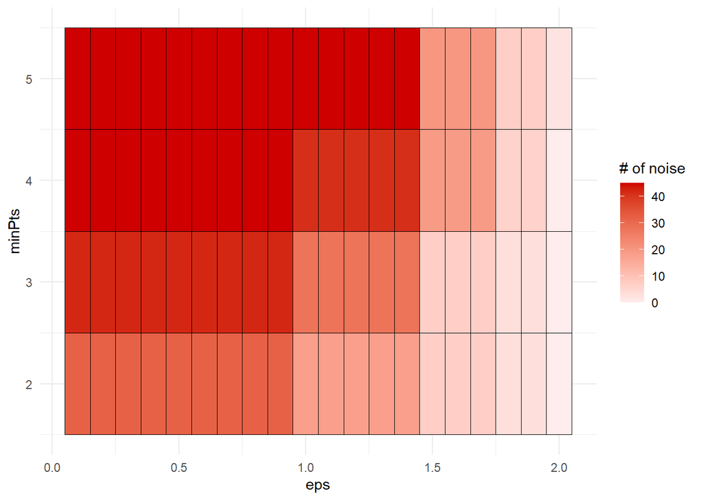

從表格和圖形，我們可以發現若將半徑設定為 2，且最小路線數設定為 2，此時噪點數會是最少的，達成我們最小化噪點數的目的。但事實上觀察表格可以發現，在此情境下只分類程一群，表示所有 DRTS 路線都是在同一個分群中，並不是我們所預期的結果。或許可以挑半徑設定為 1.5，且最小路線數設定為 2 之情境，此時可以分成 7 條路線，且只有 7 個噪點。

最後再來看看我們「半徑設定為 1.5，最小路線數設定為 2」 的分類結果!!

| X | public | private | PPP | urban | urban.or.rural | rural | virtual | PT.stop | D2D | Door.to.station | virtual.to.station | fixed.route | DRT | mixed.route | phone | web | APP | cluster |
| --- | --- | --- | --- | --- | --- | --- | --- | --- | --- | --- | --- | --- | --- | --- | --- | --- | --- | --- |
| BT let’s go | 1 | 0 | 0 | 1 | 0 | 0 | 0 | 1 | 0 | 0 | 0 | 1 | 0 | 0 | 1 | 1 | 1 | 1 |
| Mobility bus | 1 | 0 | 0 | 1 | 0 | 0 | 0 | 0 | 1 | 0 | 0 | 0 | 1 | 0 | 1 | 1 | 1 | 2 |
| Edmonton Transit Service | 1 | 0 | 0 | 1 | 0 | 0 | 0 | 1 | 0 | 0 | 0 | 1 | 0 | 0 | 1 | 1 | 1 | 1 |
| NRT OnDemand | 1 | 0 | 0 | 0 | 0 | 1 | 0 | 1 | 1 | 0 | 0 | 0 | 0 | 1 | 1 | 0 | 1 | 3 |
| Chair-A-Van | 1 | 0 | 0 | 0 | 0 | 1 | 1 | 0 | 0 | 0 | 0 | 1 | 0 | 0 | 1 | 0 | 1 | 4 |
| Wheel-Trans | 1 | 0 | 0 | 1 | 0 | 0 | 0 | 0 | 1 | 0 | 0 | 0 | 1 | 0 | 1 | 0 | 0 | 2 |
| Dial-a-Ride transit | 1 | 0 | 0 | 0 | 1 | 0 | 0 | 1 | 1 | 0 | 0 | 0 | 0 | 1 | 1 | 0 | 1 | 3 |
| Transit Plus (Handi-Transit) | 1 | 0 | 0 | 1 | 0 | 0 | 0 | 0 | 1 | 0 | 0 | 0 | 1 | 0 | 1 | 1 | 0 | 2 |
| Kan-go | 1 | 0 | 0 | 0 | 1 | 0 | 0 | 0 | 0 | 1 | 0 | 0 | 0 | 1 | 1 | 1 | 0 | 5 |
| Telebus | 1 | 0 | 0 | 0 | 0 | 1 | 0 | 0 | 1 | 1 | 0 | 0 | 0 | 1 | 1 | 1 | 0 | 5 |
| Keolis Downer | 1 | 0 | 0 | 1 | 0 | 0 | 1 | 0 | 0 | 0 | 0 | 1 | 0 | 0 | 1 | 1 | 1 | 1 |
| Butler Area Rural Transit (BART) | 1 | 0 | 0 | 0 | 0 | 1 | 0 | 0 | 1 | 0 | 0 | 0 | 1 | 0 | 1 | 1 | 0 | 2 |
| Bay area rapid transit (BART) | 1 | 0 | 0 | 1 | 0 | 0 | 0 | 1 | 0 | 1 | 0 | 0 | 0 | 1 | 1 | 1 | 1 | 0 |
| FlexRide (Call-n-Ride service) | 1 | 0 | 0 | 0 | 1 | 0 | 1 | 1 | 0 | 1 | 0 | 0 | 0 | 1 | 1 | 1 | 1 | 0 |
| Flex Service | 1 | 0 | 0 | 0 | 1 | 0 | 0 | 0 | 1 | 1 | 0 | 0 | 0 | 1 | 1 | 1 | 0 | 5 |
| NeighborLink | 1 | 0 | 0 | 0 | 0 | 1 | 0 | 0 | 1 | 1 | 0 | 0 | 1 | 0 | 1 | 1 | 1 | 2 |
| Pace On Demand | 1 | 0 | 0 | 0 | 1 | 0 | 0 | 1 | 0 | 0 | 0 | 1 | 0 | 0 | 1 | 1 | 1 | 1 |
| Ride on Flex | 1 | 0 | 0 | 1 | 0 | 0 | 1 | 0 | 0 | 0 | 0 | 1 | 0 | 0 | 1 | 1 | 1 | 1 |
| Access-A-Ride | 1 | 0 | 0 | 0 | 1 | 0 | 0 | 0 | 1 | 0 | 0 | 0 | 1 | 0 | 1 | 1 | 0 | 2 |
| Bee-Line Paratransit | 1 | 0 | 0 | 0 | 1 | 0 | 1 | 0 | 1 | 0 | 0 | 1 | 1 | 0 | 1 | 0 | 0 | 2 |
| Qualla Community Resident Transportation | 1 | 0 | 0 | 0 | 1 | 0 | 1 | 0 | 1 | 0 | 0 | 1 | 1 | 0 | 1 | 0 | 0 | 2 |
| Night Shuttle | 1 | 0 | 0 | 0 | 0 | 1 | 0 | 0 | 1 | 0 | 0 | 0 | 1 | 0 | 1 | 0 | 0 | 2 |
| Rural General Public Program | 1 | 0 | 0 | 0 | 0 | 1 | 0 | 0 | 1 | 0 | 0 | 0 | 1 | 0 | 1 | 0 | 0 | 2 |
| DARTS (Dial-A-Ride Transportation Services) | 1 | 0 | 0 | 0 | 1 | 0 | 0 | 1 | 1 | 0 | 0 | 0 | 0 | 1 | 1 | 0 | 0 | 3 |
| Rural General Public (RGP) | 1 | 0 | 0 | 0 | 1 | 0 | 0 | 0 | 1 | 0 | 0 | 0 | 1 | 0 | 1 | 0 | 0 | 2 |
| Tel-A-Ride Service | 1 | 0 | 0 | 0 | 1 | 0 | 1 | 0 | 0 | 0 | 0 | 1 | 0 | 0 | 1 | 0 | 1 | 4 |
| MetroAccess Paratransit | 1 | 0 | 0 | 0 | 1 | 0 | 0 | 0 | 1 | 0 | 0 | 0 | 1 | 0 | 1 | 1 | 0 | 2 |
| Netliner | 1 | 0 | 0 | 0 | 1 | 0 | 1 | 1 | 0 | 0 | 0 | 1 | 0 | 0 | 1 | 1 | 0 | 1 |
| Allygator | 0 | 1 | 0 | 1 | 0 | 0 | 0 | 0 | 1 | 0 | 0 | 0 | 1 | 0 | 0 | 0 | 1 | 0 |
| Berlkoenig | 0 | 0 | 1 | 1 | 0 | 0 | 1 | 1 | 0 | 0 | 0 | 1 | 0 | 0 | 0 | 0 | 1 | 6 |
| EcoBus | 0 | 0 | 1 | 1 | 0 | 1 | 0 | 0 | 1 | 0 | 0 | 0 | 1 | 0 | 1 | 1 | 1 | 0 |
| Ioki Shuttle | 0 | 0 | 1 | 0 | 1 | 0 | 0 | 0 | 0 | 1 | 0 | 0 | 0 | 1 | 0 | 0 | 1 | 7 |
| MOIA | 0 | 0 | 1 | 1 | 0 | 0 | 1 | 0 | 0 | 0 | 0 | 1 | 0 | 0 | 0 | 0 | 0 | 6 |
| IsarTiger | 0 | 0 | 1 | 1 | 0 | 0 | 0 | 1 | 0 | 0 | 0 | 1 | 0 | 0 | 0 | 0 | 1 | 6 |
| SSB Flex | 0 | 0 | 1 | 1 | 0 | 0 | 1 | 0 | 0 | 0 | 0 | 1 | 0 | 0 | 0 | 0 | 1 | 6 |
| Flexigo | 0 | 0 | 1 | 0 | 1 | 0 | 0 | 0 | 1 | 1 | 0 | 0 | 0 | 1 | 0 | 1 | 1 | 7 |
| R?sa’Est | 0 | 0 | 1 | 0 | 1 | 0 | 0 | 0 | 0 | 0 | 1 | 1 | 0 | 0 | 1 | 1 | 1 | 0 |
| Chronopro | 0 | 0 | 1 | 1 | 1 | 0 | 0 | 0 | 0 | 1 | 0 | 0 | 0 | 1 | 0 | 0 | 0 | 7 |
| ViaVan | 0 | 1 | 0 | 1 | 0 | 0 | 1 | 0 | 0 | 0 | 0 | 1 | 0 | 0 | 0 | 0 | 0 | 6 |
| Breng flex | 0 | 0 | 1 | 0 | 1 | 0 | 1 | 1 | 0 | 0 | 0 | 1 | 0 | 0 | 1 | 0 | 1 | 0 |
| Slide | 0 | 1 | 0 | 1 | 0 | 0 | 1 | 0 | 0 | 0 | 0 | 1 | 0 | 0 | 0 | 0 | 1 | 6 |
| London Smart Ride | 0 | 1 | 0 | 1 | 0 | 0 | 1 | 0 | 0 | 0 | 0 | 1 | 0 | 0 | 0 | 0 | 1 | 6 |
| ViaVan | 1 | 0 | 0 | 0 | 1 | 0 | 1 | 0 | 0 | 0 | 0 | 1 | 0 | 0 | 0 | 0 | 0 | 4 |
| Chariot | 0 | 1 | 0 | 0 | 1 | 0 | 0 | 1 | 0 | 0 | 0 | 1 | 0 | 0 | 0 | 0 | 1 | 0 |
| PickMeUp | 0 | 1 | 0 | 1 | 0 | 0 | 1 | 0 | 0 | 0 | 0 | 1 | 0 | 0 | 0 | 0 | 1 | 6 |

以上只是目前我想到的方法，或許還有更好的設定參數方法，可以思考看看!!